# Time Series - Homework #3

Luke Schwenke

2023-07-10

# Question 1

Load the usgdp.rda dataset and split it into a training dataset (1960 - 2012) and a test dataset (2013 - 2017)

```r
load('usgdp.rda')

# convert to data frame and select GDP column
gdp <- as.data.frame(usgdp)
gdp <- gdp[,c(3,4)]

# Train Set = 1960-2012
train <- gdp[gdp$Year <= 2012, ]
train <- ts(train$GDP, start = 1960, frequency = 1)

# Test Set = 2013-2017
test <- gdp[gdp$Year >= 2013, ]
test <- ts(test$GDP, start = 2013, frequency = 1)
```

# Question 2

Plot the training dataset. Is the Box-Cox transformation necessary for this data? Why?

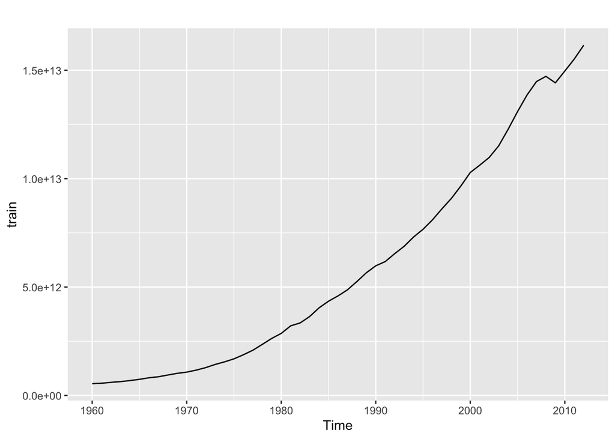

```r
autoplot(train)
```

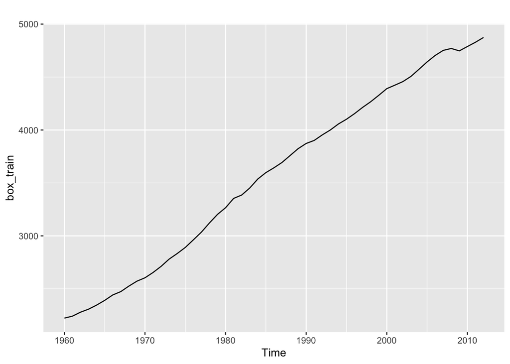

```r
lambda_val <- BoxCox.lambda(train)
box_train <- BoxCox(train, lambda=lambda_val)
autoplot(box_train)
```

**Answer: A Box-Cox transformation should be used as the variance is slightly changing. Comparing the time plots of the non-transformed and the Box Cox transformed shows the transformed one is more constant (linear) in variance**

# Question 3

Plot the 1st and 2nd order difference of the data. Apply KPSS Test for Stationarity to determine which difference order results in a stationary dataset.

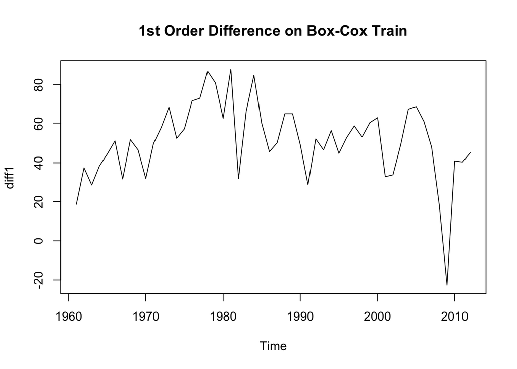

```r
diff1 <- diff(box_train)
plot(diff1, main = "1st Order Difference on Box-Cox Train")
```

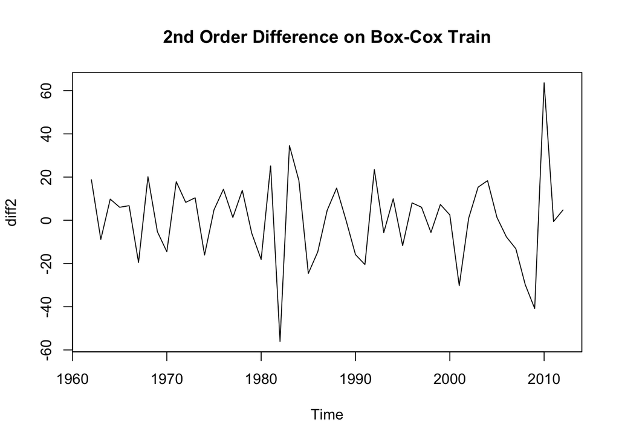

```r
# 2nd order difference
diff2 <- diff(diff1)
plot(diff2, main = "2nd Order Difference on Box-Cox Train")
```

```r
# Testing 1st order difference
kpss_test_diff1 <- kpss.test(diff1)
print(kpss_test_diff1)
```

```
##
##  KPSS Test for Level Stationarity
##
## data:  diff1
## KPSS Level = 0.23261, Truncation lag parameter = 3, p-value = 0.1
```

```r
# Testing 2nd order difference
kpss_test_diff2 <- kpss.test(diff2)
print(kpss_test_diff2)
```

```
##
##  KPSS Test for Level Stationarity
##
## data:  diff2
## KPSS Level = 0.10115, Truncation lag parameter = 3, p-value = 0.1
```

**Answer:** The first-order differencing returned a p-value of 0.1. This means we Fail to Reject the null hypothesis at a 5% significance level and conclude the data is stationary. The second-order differencing also returned a p-value of 0.1. This means we Fail to Reject the null hypothesis at a 5% level and conclude the data is stationary. **Therefore both first and second-order differencing are valid for this dataset.**

# Question 4

Fit a suitable ARIMA model to the training dataset using the auto.arima() function. Remember to transform the data first, if necessary, by setting the 𝑙𝑎𝑚𝑏𝑑𝑎 argument. Report the resulting 𝑝, 𝑑, 𝑞 and the coefficients values.

```r
print('Auto-ARIMA on Train')
```

```
## [1] "Auto-ARIMA on Train"
```

```r
train_auto <- auto.arima(train, trace=TRUE, lambda="auto")
```

```
##
##  ARIMA(2,1,2) with drift         : 454.9046
##  ARIMA(0,1,0) with drift         : 458.4581
##  ARIMA(1,1,0) with drift         : 448.1
##  ARIMA(0,1,1) with drift         : 450.3305
##  ARIMA(0,1,0)                    : 565.303
##  ARIMA(2,1,0) with drift         : 450.4211
##  ARIMA(1,1,1) with drift         : 450.4127
##  ARIMA(2,1,1) with drift         : 452.6492
##  ARIMA(1,1,0)                    : 460.9717
##
##  Best model: ARIMA(1,1,0) with drift
```

```r
arimaorder(train_auto)
```

```
## p d q
## 1 1 0
```

```r
Arima(train, order=c(1,1,0), lambda = "auto")
```

```
## Series: train
## ARIMA(1,1,0)
## Box Cox transformation: lambda= 0.2310592
##
## Coefficients:
##          ar1
##       0.9273
## s.e.  0.0445
##
## sigma^2 = 375.1:  log likelihood = -228.36
## AIC=460.73   AICc=460.97   BIC=464.63
```

Coefficients: ar1 = 0.9273 | s.e. = 0.0445

# Question 5

Compute the sample Extended ACF (EACF) and use the Arima() function to try some other plausible models by experimenting with the orders chosen. Limit your models to 𝑞, 𝑝 ≤ 2 and 𝑑 ≤ 2. Use the model summary() function to compare the Corrected Akaike information criterion (i.e., AICc) values (Note: Smaller values indicated better models).

```r
#tsdisplay(train)

eacf(box_train)
```

```
## AR/MA
##   0 1 2 3 4 5 6 7 8 9 10 11 12 13
## 0 x x x x x x x x x x x  x  o  o
## 1 x o o o o x o o o o o  o  o  o
## 2 o o o o o o o o o o o  o  o  o
## 3 x o o o o o o o o o o  o  o  o
## 4 x o o o o o o o o o o  o  o  o
## 5 x o o o o o o o o o o  o  o  o
## 6 x o o x o o o o o o o  o  o  o
## 7 x x o o o o o o o o o  o  o  o
```

```r
# Possible Combinations ARIMA(p,d,q)
## 1 = (p=1, d=1, q=1)
## 2 = (p=1, d=1, q=2)
## 3 = (p=2, d=1, q=1)
## 4 = (p=2, d=2, q=0)
## 5 = (p=2, d=2, q=2)

combo_1 = Arima(train, order=c(1,1,1), lambda="auto")
combo_2 = Arima(train, order=c(1,1,2), lambda="auto")
combo_3 = Arima(train, order=c(2,1,1), lambda="auto")
combo_4 = Arima(train, order=c(2,2,0), lambda="auto")
combo_5 = Arima(train, order=c(2,2,1), lambda="auto")
combo_6 = Arima(train, order=c(2,2,2), lambda="auto")

# Evaluate
for (model in list(combo_1, combo_2, combo_3, combo_4, combo_5, combo_6)) {
  print(summary(model))
  cat("\n")
}
```

```
## Series: train
## ARIMA(1,1,1)
## Box Cox transformation: lambda= 0.2310592
##
## Coefficients:
##          ar1      ma1
##       0.9890  -0.6489
## s.e.  0.0137   0.1413
##
## sigma^2 = 324.5:  log likelihood = -224.25
## AIC=454.51   AICc=455.01   BIC=460.36
##
## Training set error measures:
##                       ME         RMSE         MAE       MPE    MAPE      MASE
## Training set -1846557525 169640449652 96880663852 0.4340388 1.68826 0.3107517
##                   ACF1
## Training set 0.2655602
##
## Series: train
## ARIMA(1,1,2)
## Box Cox transformation: lambda= 0.2310592
##
## Coefficients:
##          ar1      ma1      ma2
##       0.9927  -0.4893  -0.2200
## s.e.  0.0102   0.1394   0.1326
##
## sigma^2 = 313.5:  log likelihood = -222.88
## AIC=453.76   AICc=454.61   BIC=461.56
##
## Training set error measures:
##                       ME         RMSE         MAE       MPE     MAPE      MASE
## Training set -4760554416 157198227265 89078684149 0.4292945 1.659386 0.2857263
##                   ACF1
## Training set 0.1011801
##
## Series: train
## ARIMA(2,1,1)
## Box Cox transformation: lambda= 0.2310592
##
```

[output cut: 52 more lines]

```
## Box Cox transformation: lambda= 0.2310592
##
## Coefficients:
##          ar1      ar2      ma1     ma2
##       1.2129  -0.5423  -1.8215  1.0000
## s.e.  0.1253   0.1343   0.1189  0.1274
##
## sigma^2 = 274.5:  log likelihood = -215.87
## AIC=441.75   AICc=443.08   BIC=451.41
##
## Training set error measures:
##                        ME         RMSE         MAE        MPE     MAPE
## Training set -15803193851 140521467360 76861927797 0.08285428 1.425137
##                   MASE       ACF1
## Training set 0.2465401 0.03151772
```

**Answer:**

- Combination #1 - ARIMA(1,1,1) - AICc = 455.01
- Combination #2 - ARIMA(1,1,2) - AICc = 454.61
- Combination #3 - ARIMA(2,1,1) - AICc = 454.89
- Combination #4 - ARIMA(2,2,0) - AICc = 447.63
- Combination #5 - ARIMA(2,2,1) - AICc = 444.47
- Combination #6 - ARIMA(2,2,2) - AICc = 443.08 (BEST)

**The best combination on the train dataset was Box-Cox Transformed ARIMA(2,2,2) with an AICc of 443.08**

# Question 6

Use the model chosen in Question 4 to forecast and plot the GDP forecasts with 80 and 95 % confidence levels for 2013 - 2017 (Test Period)

```r
fit <- Arima(train, order = c(2,2,2), lambda="auto")

fcast <- forecast(fit, h=5, level = c(.8, .95))
fcast
```

```
##      Point Forecast        Lo 80        Hi 80        Lo 95        Hi 95
## 2013   1.666088e+13 1.634602e+13 1.698038e+13 1.618121e+13 1.715141e+13
## 2014   1.701850e+13 1.646476e+13 1.758644e+13 1.617730e+13 1.789294e+13
## 2015   1.727030e+13 1.651912e+13 1.804746e+13 1.613179e+13 1.846960e+13
## 2016   1.747681e+13 1.654507e+13 1.844839e+13 1.606756e+13 1.897924e+13
## 2017   1.768791e+13 1.656030e+13 1.887365e+13 1.598621e+13 1.952558e+13
```

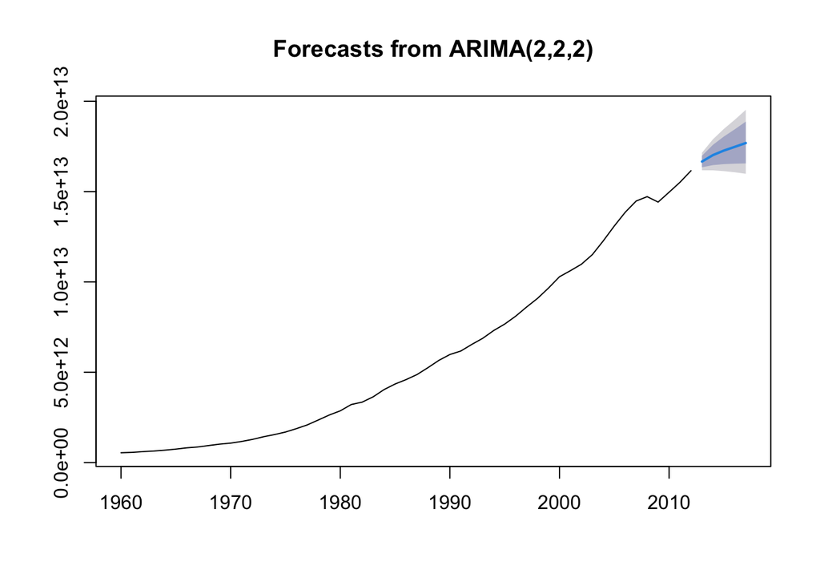

```r
#win.graph(width=12, height=6,pointsize=12)
plot(fcast)
```

# Question 7

Compare your forecasts with the actual values using error = actual - estimate and plot the errors. (Note: Use the forecast $mean element for the forecast estimate)

```r
fcast$mean
```

```
## Time Series:
## Start = 2013
## End = 2017
## Frequency = 1
## [1] 1.666088e+13 1.701850e+13 1.727030e+13 1.747681e+13 1.768791e+13
```

```r
errors = test - fcast$mean
errors
```

```
## Time Series:
## Start = 2013
## End = 2017
## Frequency = 1
## [1] 3.063704e+10 4.091107e+11 8.504189e+11 1.147664e+12 1.702698e+12
```

```r
#plot(fcast$mean)
#plot(test)
```

# Question 8

Calculate the sum of squared errors.

```r
sum(errors^2)
```

```
## [1] 5.107836e+24
```

# Question 9

Use the naive() function to forecast for 2013 - 2017 (Test Period.) Did your best model beat the naïve approach?

```r
n_fcast <- naive(train, h=5)
n_fcast$mean
```

```
## Time Series:
## Start = 2013
## End = 2017
## Frequency = 1
## [1] 1.615526e+13 1.615526e+13 1.615526e+13 1.615526e+13 1.615526e+13
```

```r
n_errors = test - n_fcast$mean

sum(n_errors**2)
```

```
## [1] 2.233402e+25
```

```r
paste('Naive Errors:', sum(n_errors**2))
```

```
## [1] "Naive Errors: 2.2334021274842e+25"
```

```r
paste('My Model Errors:', sum(errors**2))
```

```
## [1] "My Model Errors: 5.10783568586916e+24"
```

**Answer:** Yes, my model beat the Naive model. My model had errors 5.11e+24 and the Naive model had errors 2.23e+25